# Coursera Machine Learning Course Project

Katie Groskreutz

Wednesday, September 07, 2016

Background

Using devices such as Jawbone Up, Nike FuelBand, and Fitbit it is now possible to collect a large amount of data about personal activity relatively inexpensively. These type of devices are part of the quantified self movement - a group of enthusiasts who take measurements about themselves regularly to improve their health, to find patterns in their behavior, or because they are tech geeks. One thing that people regularly do is quantify how much of a particular activity they do, but they rarely quantify how well they do it. In this project, your goal will be to use data from accelerometers on the belt, forearm, arm, and dumbell of 6 participants. They were asked to perform barbell lifts correctly and incorrectly in 5 different ways. More information is available from the website here: http://groupware.les.inf.puc-rio.br/har (see the section on the Weight Lifting Exercise Dataset).

The goal of your project is to predict the manner in which they did the exercise. This is the “classe” variable in the training set. You may use any of the other variables to predict with. You should create a report describing how you built your model, how you used cross validation, what you think the expected out of sample error is, and why you made the choices you did. You will also use your prediction model to predict 20 different test cases.

The first step is to load the data and libraries.

```r
library(randomForest)
library(caret)
library(rpart)
library(RANN)
set.seed(33833)

training <- read.csv("C:/Users/518046/Desktop/MachineLearning/Week4/CourseProject/pml-training.csv", na.strings=c("#DIV/0!"))
testing <- read.csv("C:/Users/518046/Desktop/MachineLearning/Week4/CourseProject/pml-testing.csv", na.strings=c("#DIV/0!"))
```

Data Exploration and Partitioning

```r
prop.table(table(training$classe))
```

```
##
##         A         B         C         D         E
## 0.2843747 0.1935073 0.1743961 0.1638977 0.1838243
```

```r
#Partition the training set into other training and testing set
trainRows <- createDataPartition(training$classe, p = 0.8, list = FALSE)
train <- training[trainRows,]
test <- training[-trainRows,]
```

Data Cleaning and Preprocessing

```r
#Remove Columns with near zero variance
nzvCols <- nearZeroVar(train)
train <- train[-nzvCols]
test <- test[-nzvCols]

#Remove near zero variance columns from original testing data
testing <- testing[-nzvCols]

#Determine which columns are numeric
numericCols <- which(lapply(train,class) %in% c('numeric'))

#Preprocess data using K nearest neighbors impute
preProcObj <- preProcess(train[,numericCols], method = c("knnImpute"))
trainingPredict <- predict(preProcObj, train[,numericCols])
testing <- predict(preProcObj, testing[,numericCols])
testingPredict <- predict(preProcObj, test[,numericCols])

#Add classe Var back to dataset
trainingPredict <- cbind(train$classe,trainingPredict)
names(trainingPredict)[1] <- 'classe' #change name back to classe
testingPredict <- cbind(test$classe,testingPredict)
names(testingPredict)[1] <- 'classe'
```

Cross validtion

```r
#Partition rows into training and crossvalidation
crossvRows <- createDataPartition(trainingPredict$classe, p = 0.8)[[1]]
crossvtest <- trainingPredict[-crossvRows,]
crossvtrain <- trainingPredict[crossvRows,]

trainmod_rf<-train(classe~.,method="rf",na.action = na.exclude,data=crossvtrain)
```

Train Models

```r
###Train MOdels###
#Random Forest
##mod2 <- train(classe ~ ., method="rf",data=predtrain,trControl=trainControl(method="cv"),number=3)
modRF <- train(classe ~ ., data=trainingPredict, method="rf")
predRF <- predict(modRF, trainingPredict)
confusionMatrix(predRF, trainingPredict$classe)
```

```
## Confusion Matrix and Statistics
##
##           Reference
## Prediction    A    B    C    D    E
##          A 4464    0    0    0    0
##          B    0 3038    0    0    0
##          C    0    0 2738    0    0
##          D    0    0    0 2573    0
##          E    0    0    0    0 2886
##
## Overall Statistics
##
##                Accuracy : 1
##                  95% CI : (0.9998, 1)
##     No Information Rate : 0.2843
##     P-Value [Acc > NIR] : < 2.2e-16
##
##                   Kappa : 1
##  Mcnemar's Test P-Value : NA
##
## Statistics by Class:
##
##                      Class: A Class: B Class: C Class: D Class: E
## Sensitivity            1.0000   1.0000   1.0000   1.0000   1.0000
## Specificity            1.0000   1.0000   1.0000   1.0000   1.0000
## Pos Pred Value         1.0000   1.0000   1.0000   1.0000   1.0000
## Neg Pred Value         1.0000   1.0000   1.0000   1.0000   1.0000
## Prevalence             0.2843   0.1935   0.1744   0.1639   0.1838
## Detection Rate         0.2843   0.1935   0.1744   0.1639   0.1838
## Detection Prevalence   0.2843   0.1935   0.1744   0.1639   0.1838
## Balanced Accuracy      1.0000   1.0000   1.0000   1.0000   1.0000
```

```r
predRFTest <- predict(modRF, testingPredict)
confusionMatrix(predRFTest, testingPredict$classe)
```

```
## Confusion Matrix and Statistics
##
##           Reference
## Prediction    A    B    C    D    E
##          A 1111    3    0    0    0
##          B    4  753    3    0    0
##          C    0    2  676    3    2
##          D    1    0    5  640    0
##          E    0    1    0    0  719
##
## Overall Statistics
##
##                Accuracy : 0.9939
##                  95% CI : (0.9909, 0.9961)
##     No Information Rate : 0.2845
##     P-Value [Acc > NIR] : < 2.2e-16
##
##                   Kappa : 0.9923
##  Mcnemar's Test P-Value : NA
##
## Statistics by Class:
##
##                      Class: A Class: B Class: C Class: D Class: E
## Sensitivity            0.9955   0.9921   0.9883   0.9953   0.9972
## Specificity            0.9989   0.9978   0.9978   0.9982   0.9997
## Pos Pred Value         0.9973   0.9908   0.9898   0.9907   0.9986
## Neg Pred Value         0.9982   0.9981   0.9975   0.9991   0.9994
## Prevalence             0.2845   0.1935   0.1744   0.1639   0.1838
## Detection Rate         0.2832   0.1919   0.1723   0.1631   0.1833
## Detection Prevalence   0.2840   0.1937   0.1741   0.1647   0.1835
## Balanced Accuracy      0.9972   0.9949   0.9931   0.9968   0.9985
```

```r
#Gradient Boosted Model
#modGBM <- train(classe ~ ., data=trainingPredict, method="gbm")
#predGBM <- predict(modGBM, trainingPredict)
#confusionMatrix(predGBM, trainingPredict$classe)

#Linear Discriminant Analysis
#modLDA <- train(classe ~ ., data=trainingPredict, method="lda")
#predLDA <- predict(modLDA, trainingPredict)
#confusionMatrix(predLDA, trainingPredict$classe)
```

Results

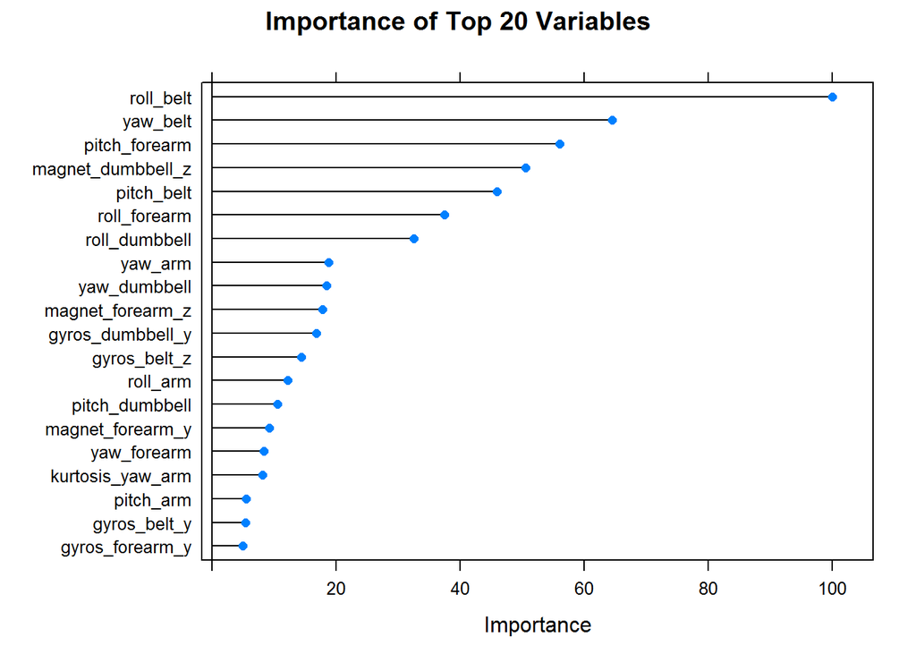

```r
#Random Forest Variable Importance
varImpObj <- varImp(modRF)
plot(varImpObj, main = "Importance of Top 20 Variables", top = 20)
```

```r
#Courera test data
pml_write_files = function(x){
  n = length(x)
  for(i in 1:n){
    filename = paste0("problem_id_",i,".txt")
    write.table(x[i],file=filename,quote=FALSE,row.names=FALSE,col.names=FALSE)
  }
}
x <- testing

answers <- predict(modRF, newdata=x)
answers
```

```
##  [1] B A B A A E D B A A B C B A E E A B B B
## Levels: A B C D E
```